# Project: TMDB Movie Data Analysis

- Introduction
- Data Wrangling
- Exploratory Data Analysis
- Conclusions

## Introduction

This report examines TMDB Movie Dataset. Here, I am interested in finding the important features related with the voting criteria for a particular movie of a genre, which has been votes by spectators. This report anlyses the relationship between vote(average) of a movie with other features like popularity or revenue generated or the budget. I have also mentioned overview of the correlation between the variables in this report.

There are few questions that will be answered by the end of this report:

1. What are the correaltions between the feature variables in this dataset?
2. Is their any trend between the number of spectators voting for a partcular movie and revenue generated?
3. Is their any trend between the number of spectators voting for a particular movie and the popularity of the movie?
4. Whether a more popular movie will generate higher revenue or not?
5. What is the length of the movies being released? Also, how is it different nowadays, in terms of the number of movies being released every year?

### Below are the columns description of the dataset:

- id - A unique identifier for each movie.
- imdb_id - Imdb_id is also an identifier for each movie.
- cast - The name of lead and supporting actors.
- director - The name of Director.
- budget - The budget in which the movie was made.
- genre - The genre of the movie, Action, Comedy ,Thriller etc.
- homepage - A link to the homepage of the movie.
- keywords - The keywords or tags related to the movie.
- original_title - The title of the movie before translation or adaptation.
- overview - A brief description of the movie.
- popularity - A numeric quantity specifying the movie popularity.
- production_companies - The production house of the movie.
- release_date - The date on which it was released.
- revenue - The worldwide revenue generated by the movie.
- runtime - The running time of the movie in minutes.
- status - "Released" or "Rumored".
- tagline - Movie's tagline.
- vote_average - average ratings the movie recieved.
- vote_count - the count of votes recieved.

```python
import numpy as np
import pandas as pd
import matplotlib.pyplot as plt
import seaborn as sns


pd.set_option('display.max_columns',200)
pd.set_option('display.max_rows',200)

%matplotlib inline
%config InlineBackend.format_figure = 'retina'
```

## Data Wrangling

I have loaded all the libraries that will be used during the analysis of this dataset. Using Pandas library, I have loaded the dataset in jupyter notebook.

### General Properties

```python
df = pd.read_csv('https://d17h27t6h515a5.cloudfront.net/topher/2017/October/59dd1c4c_tmdb-movies/tmdb-movies.csv')
df.head()
```

|  | id | imdb_id | popularity | budget | revenue | original_title | cast | homepage | director | tagline | keywords | overview | runtime | genres | production_companies | release_date | vote_count | vote_average | release_year | budget_adj | revenue_adj |
| --- | --- | --- | --- | --- | --- | --- | --- | --- | --- | --- | --- | --- | --- | --- | --- | --- | --- | --- | --- | --- | --- |
| 0 | 135397 | tt0369610 | 32.985763 | 150000000 | 1513528810 | Jurassic World | Chris Pratt\|Bryce Dallas Howard\|Irrfan Khan\|Vi... | http://www.jurassicworld.com/ | Colin Trevorrow | The park is open. | monster\|dna\|tyrannosaurus rex\|velociraptor\|island | Twenty-two years after the events of Jurassic ... | 124 | Action\|Adventure\|Science Fiction\|Thriller | Universal Studios\|Amblin Entertainment\|Legenda... | 6/9/15 | 5562 | 6.5 | 2015 | 1.379999e+08 | 1.392446e+09 |
| 1 | 76341 | tt1392190 | 28.419936 | 150000000 | 378436354 | Mad Max: Fury Road | Tom Hardy\|Charlize Theron\|Hugh Keays-Byrne\|Nic... | http://www.madmaxmovie.com/ | George Miller | What a Lovely Day. | future\|chase\|post-apocalyptic\|dystopia\|australia | An apocalyptic story set in the furthest reach... | 120 | Action\|Adventure\|Science Fiction\|Thriller | Village Roadshow Pictures\|Kennedy Miller Produ... | 5/13/15 | 6185 | 7.1 | 2015 | 1.379999e+08 | 3.481613e+08 |
| 2 | 262500 | tt2908446 | 13.112507 | 110000000 | 295238201 | Insurgent | Shailene Woodley\|Theo James\|Kate Winslet\|Ansel... | http://www.thedivergentseries.movie/#insurgent | Robert Schwentke | One Choice Can Destroy You | based on novel\|revolution\|dystopia\|sequel\|dyst... | Beatrice Prior must confront her inner demons ... | 119 | Adventure\|Science Fiction\|Thriller | Summit Entertainment\|Mandeville Films\|Red Wago... | 3/18/15 | 2480 | 6.3 | 2015 | 1.012000e+08 | 2.716190e+08 |
| 3 | 140607 | tt2488496 | 11.173104 | 200000000 | 2068178225 | Star Wars: The Force Awakens | Harrison Ford\|Mark Hamill\|Carrie Fisher\|Adam D... | http://www.starwars.com/films/star-wars-episod... | J.J. Abrams | Every generation has a story. | android\|spaceship\|jedi\|space opera\|3d | Thirty years after defeating the Galactic Empi... | 136 | Action\|Adventure\|Science Fiction\|Fantasy | Lucasfilm\|Truenorth Productions\|Bad Robot | 12/15/15 | 5292 | 7.5 | 2015 | 1.839999e+08 | 1.902723e+09 |
| 4 | 168259 | tt2820852 | 9.335014 | 190000000 | 1506249360 | Furious 7 | Vin Diesel\|Paul Walker\|Jason Statham\|Michelle ... | http://www.furious7.com/ | James Wan | Vengeance Hits Home | car race\|speed\|revenge\|suspense\|car | Deckard Shaw seeks revenge against Dominic Tor... | 137 | Action\|Crime\|Thriller | Universal Pictures\|Original Film\|Media Rights ... | 4/1/15 | 2947 | 7.3 | 2015 | 1.747999e+08 | 1.385749e+09 |

#### The shape of the dataset is:

```python
print('Total number of rows in the dataset are:',df.shape[0])
print('Total number of columns in the dataset are:',df.shape[1])
```

```
Total number of rows in the dataset are: 10866
Total number of columns in the dataset are: 21
```

```python
print("The columns are:")
for i,x in enumerate(df.columns):
    print(str(i)+'  :  '+str(x))
```

```
The columns are:
0  :  id
1  :  imdb_id
2  :  popularity
3  :  budget
4  :  revenue
5  :  original_title
6  :  cast
7  :  homepage
8  :  director
9  :  tagline
10  :  keywords
11  :  overview
12  :  runtime
13  :  genres
14  :  production_companies
15  :  release_date
16  :  vote_count
17  :  vote_average
18  :  release_year
19  :  budget_adj
20  :  revenue_adj
```

#### We can see that there are few missing vlaue records in the data that will be handled later.

```python
df.info()
```

```
<class 'pandas.core.frame.DataFrame'>
RangeIndex: 10866 entries, 0 to 10865
Data columns (total 21 columns):
id                      10866 non-null int64
imdb_id                 10856 non-null object
popularity              10866 non-null float64
budget                  10866 non-null int64
revenue                 10866 non-null int64
original_title          10866 non-null object
cast                    10790 non-null object
homepage                2936 non-null object
director                10822 non-null object
tagline                 8042 non-null object
keywords                9373 non-null object
overview                10862 non-null object
runtime                 10866 non-null int64
genres                  10843 non-null object
production_companies    9836 non-null object
release_date            10866 non-null object
vote_count              10866 non-null int64
vote_average            10866 non-null float64
release_year            10866 non-null int64
budget_adj              10866 non-null float64
revenue_adj             10866 non-null float64
dtypes: float64(4), int64(6), object(11)
memory usage: 1.7+ MB
```

#### There is one duplicated value which is removed below.

```python
df.duplicated().sum()
```

```
1
```

```python
df.drop_duplicates(inplace = True)
```

```python
df.describe()
```

|  | id | popularity | budget | revenue | runtime | vote_count | vote_average | release_year | budget_adj | revenue_adj |
| --- | --- | --- | --- | --- | --- | --- | --- | --- | --- | --- |
| count | 10865.000000 | 10865.000000 | 1.086500e+04 | 1.086500e+04 | 10865.000000 | 10865.000000 | 10865.000000 | 10865.000000 | 1.086500e+04 | 1.086500e+04 |
| mean | 66066.374413 | 0.646446 | 1.462429e+07 | 3.982690e+07 | 102.071790 | 217.399632 | 5.975012 | 2001.321859 | 1.754989e+07 | 5.136900e+07 |
| std | 92134.091971 | 1.000231 | 3.091428e+07 | 1.170083e+08 | 31.382701 | 575.644627 | 0.935138 | 12.813260 | 3.430753e+07 | 1.446383e+08 |
| min | 5.000000 | 0.000065 | 0.000000e+00 | 0.000000e+00 | 0.000000 | 10.000000 | 1.500000 | 1960.000000 | 0.000000e+00 | 0.000000e+00 |
| 25% | 10596.000000 | 0.207575 | 0.000000e+00 | 0.000000e+00 | 90.000000 | 17.000000 | 5.400000 | 1995.000000 | 0.000000e+00 | 0.000000e+00 |
| 50% | 20662.000000 | 0.383831 | 0.000000e+00 | 0.000000e+00 | 99.000000 | 38.000000 | 6.000000 | 2006.000000 | 0.000000e+00 | 0.000000e+00 |
| 75% | 75612.000000 | 0.713857 | 1.500000e+07 | 2.400000e+07 | 111.000000 | 146.000000 | 6.600000 | 2011.000000 | 2.085325e+07 | 3.370173e+07 |
| max | 417859.000000 | 32.985763 | 4.250000e+08 | 2.781506e+09 | 900.000000 | 9767.000000 | 9.200000 | 2015.000000 | 4.250000e+08 | 2.827124e+09 |

#### I have decided to drop the columns below because they are kind of unique identifier and are not going to help me to make an analysis. These columns are:

- id
- imdb_id
- homepage
- tagline
- overview #### Dropping these columns also handles the missing values in these columns.

```python
df.drop(['id','imdb_id','homepage','tagline','overview'],axis =1,inplace = True)
```

- cast
- keywords
- genres
- production_companies

```python
df.drop(['cast','keywords','genres','production_companies','director'],axis = 1,inplace=True)
```

```python
df.head()
```

|  | popularity | budget | revenue | original_title | runtime | release_date | vote_count | vote_average | release_year | budget_adj | revenue_adj |
| --- | --- | --- | --- | --- | --- | --- | --- | --- | --- | --- | --- |
| 0 | 32.985763 | 150000000 | 1513528810 | Jurassic World | 124 | 6/9/15 | 5562 | 6.5 | 2015 | 1.379999e+08 | 1.392446e+09 |
| 1 | 28.419936 | 150000000 | 378436354 | Mad Max: Fury Road | 120 | 5/13/15 | 6185 | 7.1 | 2015 | 1.379999e+08 | 3.481613e+08 |
| 2 | 13.112507 | 110000000 | 295238201 | Insurgent | 119 | 3/18/15 | 2480 | 6.3 | 2015 | 1.012000e+08 | 2.716190e+08 |
| 3 | 11.173104 | 200000000 | 2068178225 | Star Wars: The Force Awakens | 136 | 12/15/15 | 5292 | 7.5 | 2015 | 1.839999e+08 | 1.902723e+09 |
| 4 | 9.335014 | 190000000 | 1506249360 | Furious 7 | 137 | 4/1/15 | 2947 | 7.3 | 2015 | 1.747999e+08 | 1.385749e+09 |

## Exploratory Data Analysis

```python
df.nunique()
```

```
popularity        10814
budget              557
revenue            4702
original_title    10571
runtime             247
release_date       5909
vote_count         1289
vote_average         72
release_year         56
budget_adj         2614
revenue_adj        4840
dtype: int64
```

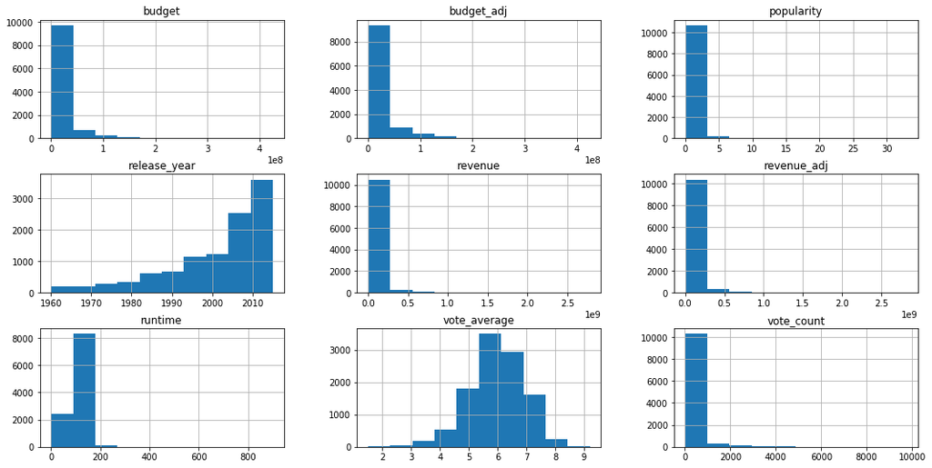

```python
df.hist(figsize=(18,9));
```

#### The histograms above give me wide knowledge of the distribution of data which I will be discussing below one by one.

### Q1. What are the correaltions between the feature variables in this dataset?

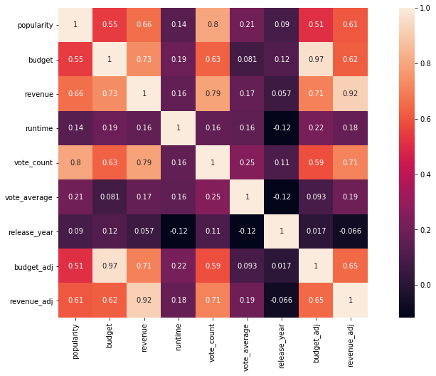

```python
plt.figure(figsize=(16,8))
sns.heatmap(df.corr(),square=True,annot=True);
```

#### Heatmap shows the pearson's correlation of the numeric data types.

We can clearly notice that there are features with high correlation like

- budject_adj has a correlation of 0.97 with budget column
- revenue_adj has a correlation of 0.92 with revenue column
- also budget and revenue have a high correlation of 0.73, so does vote_count and revenue with 0.79 Since budget_adj and revenue_adj are highly correlated with budget and revenue respectively, we take only one of these in account for further analysis.

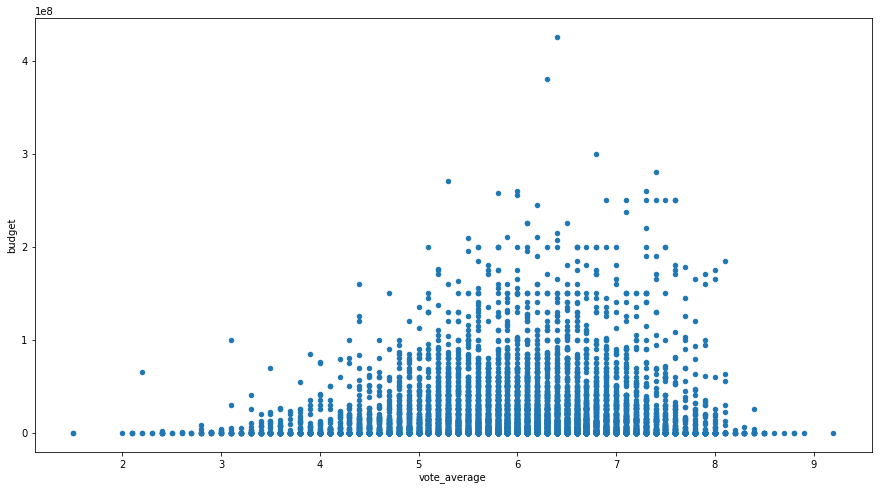

```python
df.plot(kind = 'scatter',x='vote_average',y='budget', figsize=(15,8));
```

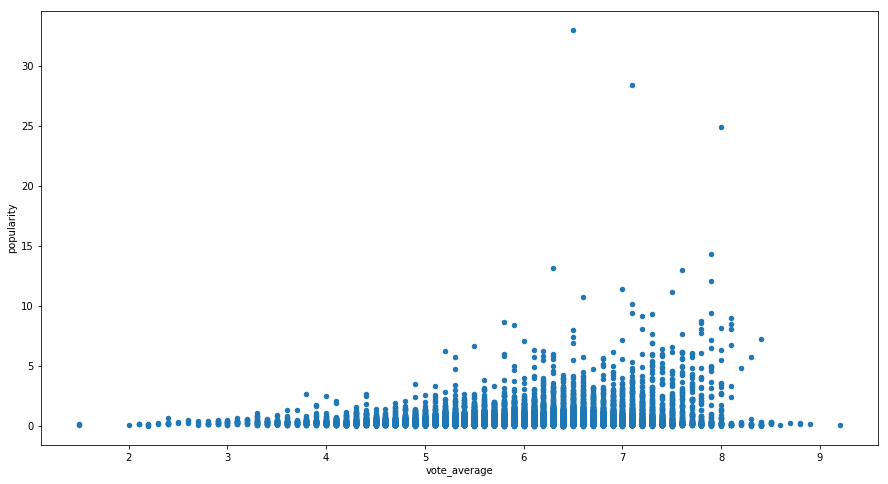

```python
df.plot(kind = 'scatter',x='vote_average',y='popularity',figsize=(15,8));
```

#### The vote and popularity also shows a weak relationship and it can be notices that it is not necessary for a highly voted movie to be very popular. Spectators tend to rate the movie higher evethough it is not as popular as other movies. Spectator count may be a consideration here.

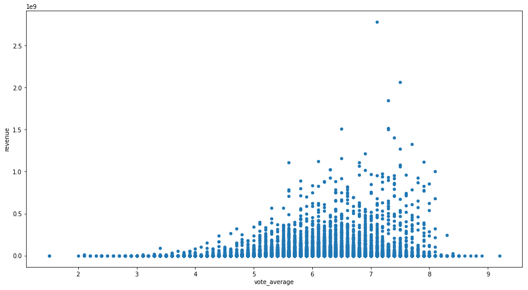

```python
df.plot(kind = 'scatter',x='vote_average',y='revenue',figsize=(15,8));
```

### Q2. Is their any trend between the number of spectators voting for a partcular movie and revenue generated?

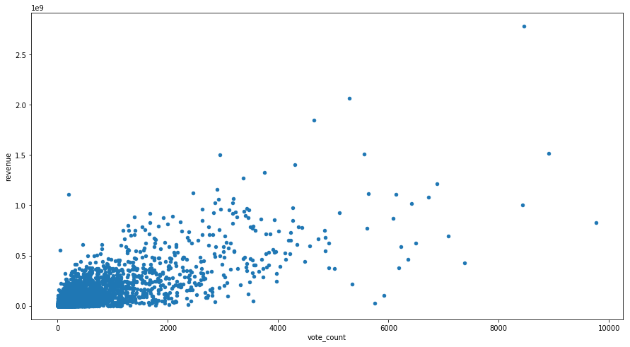

```python
df.plot(kind = 'scatter',x='vote_count',y='revenue',figsize=(15,8));
```

#### Yes. The number of spectators(vote_counts) viewing a movie has a linear relationship with the revenue generated by the movie. Its a great point which means that a more a movie is rated, the better chance of generating higher revenues.

### Q3. Is their any trend between the number of spectators voting for a particular movie and the popularity of the movie?

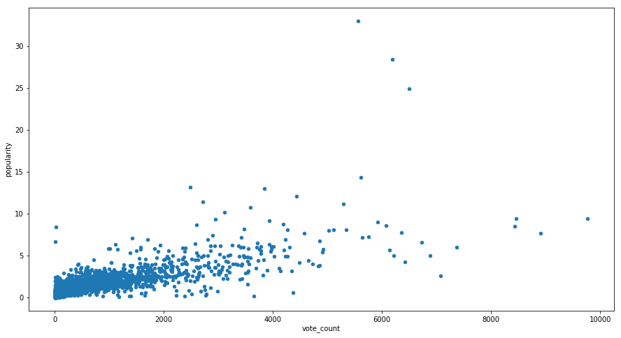

```python
df.plot(kind = 'scatter',x='vote_count',y='popularity',figsize=(15,8));
```

#### Yes. The number of spectators also has a linear relationship with the popularity of the movie, but it can also be noted that the slope of the linear line is less steeper as compared with revenue.

### Q4. Whether a more popular movie will generate higher revenue or not?

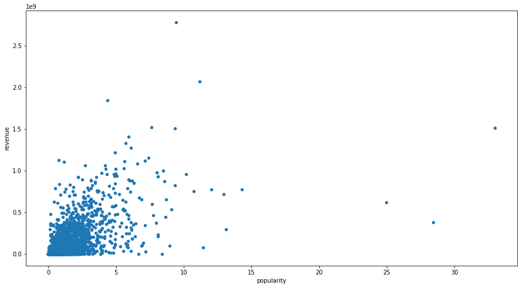

```python
df.plot(kind = 'scatter',x='popularity',y='revenue',figsize=(15,8));
```

### Q5. What is the length of the movies being released? Also, how is it different nowadays, in terms of the number of movies being released every year?

```
Text(0,0.5,'frequency')
```

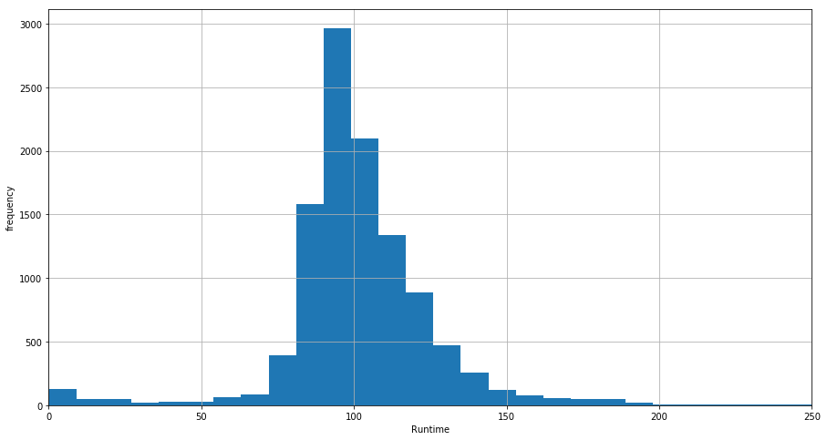

```python
df['runtime'].hist(bins=100,figsize=(15,8));
plt.xlim(0,250)
plt.xlabel('Runtime')
plt.ylabel('frequency')
```

#### It is seen that a larger number movies that are released have a runtime in range of 80 to 120 minutes. Fewer movies are released with a runtime more or less than that range. It is normally distributed curve where higher percentage of movies lies in the range of 80 to 120 minutes.

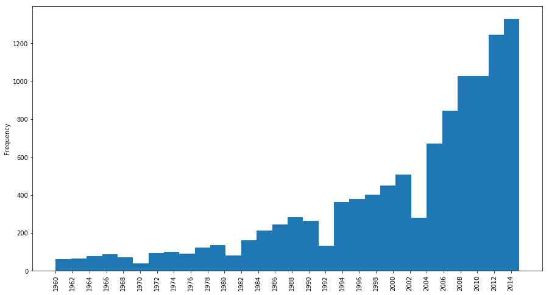

```python
df['release_year'].plot(kind='hist', bins= 30,figsize=(15,8))
plt.xticks(np.arange(1960,2016,2),rotation=90)
plt.show()
```

#### It is clear from the histogram that as years passed, there were more movies being released. It is left skewed curve with depicts that a higher number of movies were released during recent time.

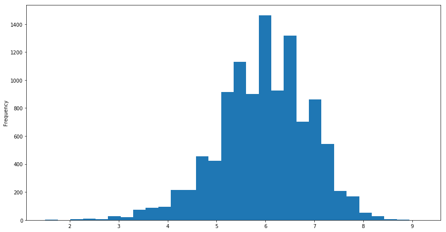

```python
df['vote_average'].plot(kind='hist', bins= 30,figsize=(15,8))
plt.show()
```

#### It can be seen from the curve that more number of the movies were voted above 5 and below 7.

```python
from subprocess import call
call(['python', '-m', 'nbconvert', 'Investigate_a_Dataset.ipynb'])
```